# Estimating Animal Home Range

Jared Stabach, Smithsonian Conservation Biology Institute

22 April 2021

# Introduction

> Many thanks to Chris Fleming for the many conversations on this topic and the development of CTMM

With the advent of modern tracking devices, we no longer can assume statistical independence between data points (IID - independent and identically distributed), a common assumption of most home range estimators. Over the past few years, a number of new methodological advances have emerged, with the Continuous Time Movement Modeling ([CTMM](https://cran.r-project.org/web/packages/ctmm/index.html)) framework leading the way on techniques to incorporate, rather than ignore, the autocorrelation structure inherent in animal movement data. The package includes functions for identifying, fitting, and applying continuous-space, continuous-time stochastic movement models to animal tracking data, including path reconstruction and home range estimation.

In this tutorial, we will follow instructions and vignettes that the package architects - Drs. Chris Fleming and Justin Calabrese - provide to create an Autocorrelated Kernel Density Estimate (AKDE) from wildebeest (*Connochaetes taurinus*) tracking data. We won’t get into the “guts” of the package. For that you’ll need to speak with Chris and Justin. Both are are an amazing resource and can answer more detailed questions about the methodology. Chris also maintains and moderates a very active [Google Group](https://groups.google.com/g/ctmm-user) and is incredibly responsive to questions about the package. Further details about the tools being developed by this quantitative team can be found on the [University of Maryland](http://biology.umd.edu/movement.html) and [Movement of Life](https://movementoflife.si.edu/analytical-tools/) websites.

Many publications exist on the framework and its implementation, including:

- Fleming, C.H., J.M. Calabrese, T.Mueller, K.A. Olson, P. Leimgruber, W.F. Fagan. 2014. From fine scale foraging to home ranges: A semi-variance approach to identifying movement modes across spatiotemporal scales. [The American Naturalist 183(5): E154-E167](https://www.journals.uchicago.edu/doi/abs/10.1086/675504).
- Fleming, C.H., W.F. Fagan, T. Mueller, K.A. Olson, P. Leimgruber, J.M. Calabrese. 2015. Rigorous home-range estimation with movement data: A new autocorrelated kernel-density estimator. [Ecology 96(5): 1182-1188](https://esajournals.onlinelibrary.wiley.com/doi/full/10.1890/14-2010.1).
- Calabrese, J.M., C.H. Fleming. 2016. Ctmm: an R package for analyzing animal relocation data as a continuous-time stochastic process. [Methods in Ecology and Evolution 7(9): 1124-1132](https://besjournals.onlinelibrary.wiley.com/doi/full/10.1111/2041-210X.12559)

Several applications of CTMM also exist, including:

- Morato, R.G., J.A. Stabach, C.H. Fleming, J.M. Calabrese, et al. 2016. Space use and movement of a neotropical top predator: The endangered jaguar. [PLOS ONE 11(16)](https://journals.plos.org/plosone/article?id=10.1371/journal.pone.0168176).

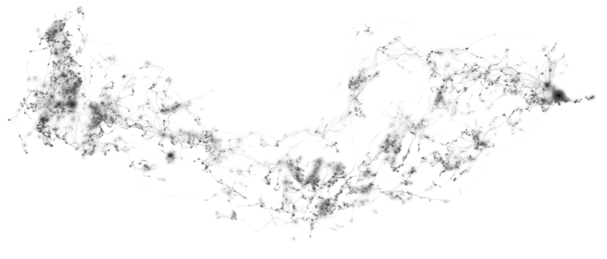

## Load Libraries

As a primary first step, we need to load required libraries.

```r
# Remove everything from memory
rm(list=ls())

# Load required libraries
library(adehabitatHR)
library(ctmm)

# Timezone
Timezone2 <- "Africa/Nairobi"

# Spatial reference information
LatLong.proj <- "+proj=longlat +ellps=WGS84 +datum=WGS84 +no_defs"  # EPSG:4326
#https://spatialreference.org/ref/esri/102022/
AEA.Africa.proj <- "+proj=aea +lat_1=20 +lat_2=-23 +lat_0=0 +lon_0=25 +x_0=0 +y_0=0 +ellps=WGS84 +datum=WGS84 +units=m +no_defs"   #ESRI:102022
```

## Load Data

Import the `.Rdata` file with the movement dataset

```r
# Load .Rda object
load(file="./Data/wild.Rdata")

# Look at the data
head(wild.Athi)
```

```
##     id           timestamp location.long location.lat external.temperature
## 1 2840 2010-10-16 16:00:00      36.84518    -1.357289                   31
## 2 2840 2010-10-16 17:00:00      36.84518    -1.357294                   28
## 3 2840 2010-10-16 18:00:00      36.84676    -1.358796                   25
## 4 2840 2010-10-16 21:01:00      36.84691    -1.360435                   24
## 5 2840 2010-10-17 00:00:00      36.84826    -1.362778                   20
## 6 2840 2010-10-17 03:00:00      36.84964    -1.363394                   18
##   gps.dop gps.fix.type.raw height.above.ellipsoid sensor.type
## 1     1.6               3D                1627.62         gps
## 2     3.2               3D                1642.64         gps
## 3     4.4               3D                1639.90         gps
## 4     2.8               3D                1630.99         gps
## 5     4.6               3D                1627.89         gps
## 6     1.6               3D                1624.66         gps
##   tag.local.identifier individual.local.identifier animal.life.stage animal.sex
## 1                 2840                       Sotua           6 years          m
## 2                 2840                       Sotua           6 years          m
## 3                 2840                       Sotua           6 years          m
## 4                 2840                       Sotua           6 years          m
## 5                 2840                       Sotua           6 years          m
## 6                 2840                       Sotua           6 years          m
##             study.site
## 1 Athi-Kaputiei Plains
## 2 Athi-Kaputiei Plains
## 3 Athi-Kaputiei Plains
## 4 Athi-Kaputiei Plains
## 5 Athi-Kaputiei Plains
## 6 Athi-Kaputiei Plains
```

# Home Range Estimation

Many home range estimators exist, as discussed in lecture. Some of these estimators, however, perform better than others. Recent research by [Noonan et al. 2018](https://esajournals.onlinelibrary.wiley.com/doi/abs/10.1002/ecm.1344) indicates that CTMM outperforms all other existing estimators, especially when data are sparse or collected for short time periods (common to GPS tracking datasets). Importantly, CTMM provides confidence intervals with point estimates, providing a measure of estimate uncertainty.

We will provide a quick example to calculate a Minimum Convex Polygon and then move on to calculating home range via CTMM.

## AdeHabitat - MCP

Minimum Convex Polygon is the oldest home range estimator. Note, however, MCP is not a statistical estimate. Instead, MCP simply places a polygon around your data and can be extremely sensitive to outliers. I would not use MCP to provide a home range estimate, but it can be useful as a very quick way to define the area where your animals were located during a tracking period.

```r
# Define projection and reproject animal 30084
Athi.sp <- SpatialPointsDataFrame(coords = wild.Athi[c("location.long","location.lat")],
                                    data = wild.Athi,
                                    proj4string = CRS(LatLong.proj))

# Reproject to Albers
Athi.albers <- spTransform(Athi.sp,
                         CRS =  CRS(AEA.Africa.proj))

# Subset datafrmae
Athi.30084 <- subset(Athi.albers, id == 30084)

# Compute MCP - Note that this is NOT a statistical estimate
Athi.mcp <- mcp(Athi.30084[,"id"], percent = 95, unin = "m", unout = "km2")
Athi.mcp
```

```
## Object of class "SpatialPolygonsDataFrame" (package sp):
##
## Number of SpatialPolygons:  1
##
## Variables measured:
##          id     area
## 30084 30084 37.30891
```

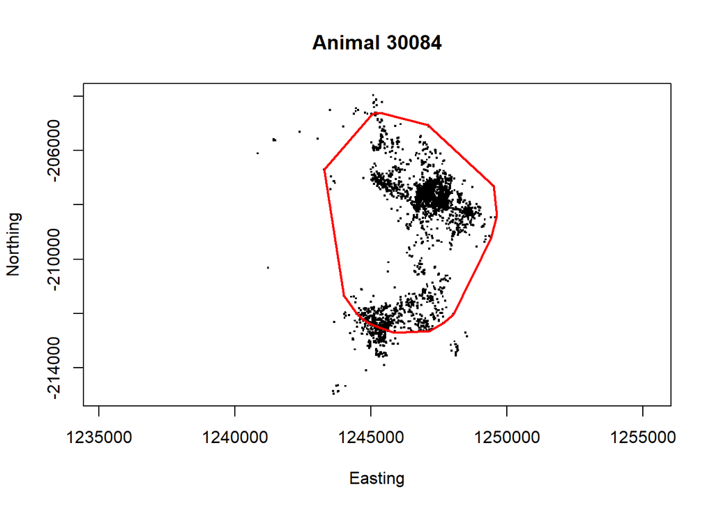

```r
# Plot Result
sp::plot(Athi.30084, pch = '.', cex=2, main=paste0("Animal ",unique(Athi.30084$id)), xlab="Easting",ylab="Northing", axes = T, asp=1)
sp::plot(Athi.mcp, col = NA, border = "red", lwd = 2, add=T)
```

## CTMM - AKDE

In its current stage of development, CTMM is meant for animals that exhibit stationary and/or resident behavior (i.e, part of the definition of Home Range). Ctmm will still fit a model for animals that exhibit other types of behaviors (i.e., migratory), but you should expect that the estimates will reflect a poor model fit (large confidence intervals). We start by importing the dataset using `as.telemetry`.

### Create Telemetry Object

[Ctmm](https://cran.r-project.org/web/packages/ctmm/index.html) requires that your dataframe conform to [Movebank naming conventions](https://www.movebank.org/cms/movebank-content/movebank-attribute-dictionary). Since we are using a wildebeest dataset that we downloaded directly from [Movebank](https://www.movebank.org/cms/movebank-main), we have nothing to worry about. We could, however, format the data ourselves and import the file as a “.csv” (`YourAnimalDF <- read.csv("YourAnimal.csv")`) before converting to a `telemetry` object. Ctmm also requires that data are projected to a flat, ideally equal area, projection and uses a default two-point projection. This should work fine for most studies. You can, however, specify the projection when data are imported, like we will do here.

```r
#  Import file into CTMM object, converting the spatial points object to a dataframe and using Albers Equal Area
Athi.sp <- as.data.frame(Athi.sp)

# Ctmm will recognize the location.long and location.lat files
# We will project to Albers Equal Area
wild <- as.telemetry(Athi.sp, timezone = TimeZone2, projection = AEA.Africa.proj, UERE=TRUE)

# How many animals?
length(wild)
```

```
## [1] 12
```

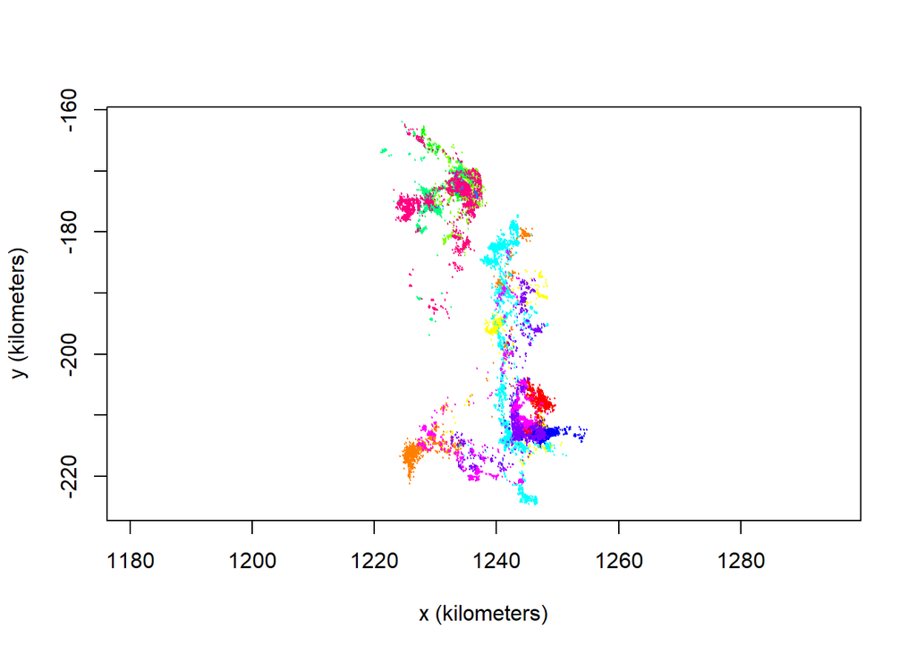

```r
# plots all in rainbow color
plot(wild, col=rainbow(length(wild))) # Okay, looks good
```

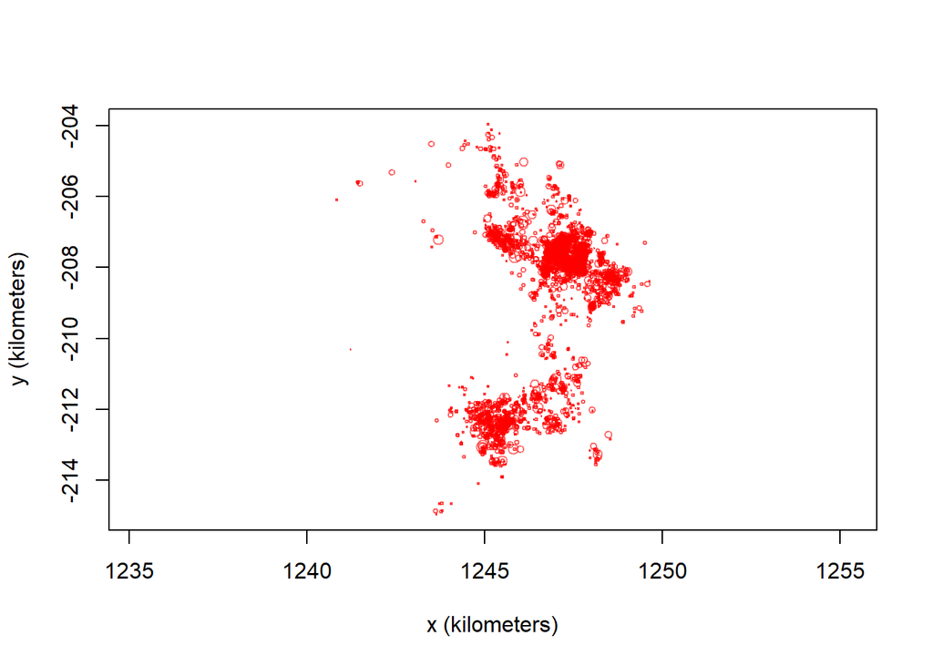

```r
# Plot a particular animal...just need to specify the number in the list
# 1 is 30084, Karbolo
An <- 1
plot(wild[[An]], col="red")
```

### Variogram Fitting & Model Selection

Variograms are an unbiased way to visualize the autocorrelation structure in data. Ctmm includes a few very nice features to estimate the parameters of the variogram model. This includes an interactive feature where the user can provide a best guess. But, just as easy, is using the function `ctmm.guess` to provide this initial guesstimate. I have never had a problem with using this feature.

The variogram represents the average square distance traveled (y-axis) within some time lag (x-axis). From the long-range behavior, we see that the variogram flattens (asymptotes) for this animal at about 1 month. This is, roughly speaking, how coarse the timeseries would need to be to assume independence in your data points (i.e., for the “no” autocorrelation assumption to hold true).

The asymptote of our variogram is around 2 km$^2$. The fact that it takes roughly 1 month for the variogram to asymptote is indicate that the movement process has a finite variance and doesn’t diffuse forever. This is roughly the time it takes for this wildebeest to cross its home range several times.

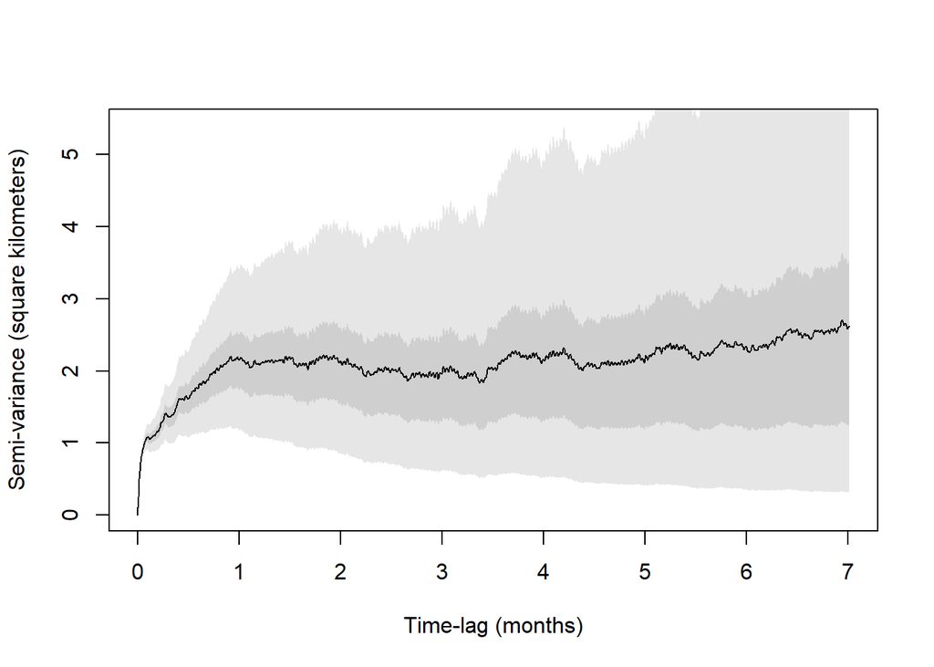

```r
# Set the dt, which in our case is hourly during the day (6 am - 6 pm) and every 3 hours at night (6 pm - 6 am), and confidence levels to display
dt <- c(1,3) %#% "hour" # The time interval of our data
level <- c(0.5, 0.95) # Confidence intervals placed on the contour estimates
xlim <- c(0,2 %#% "day") # 0-2 day window

# Variogram investigation
vg.karbolo <- variogram(wild[[An]], dt=dt)

# Plot full variogram
plot(vg.karbolo, level = level)
```

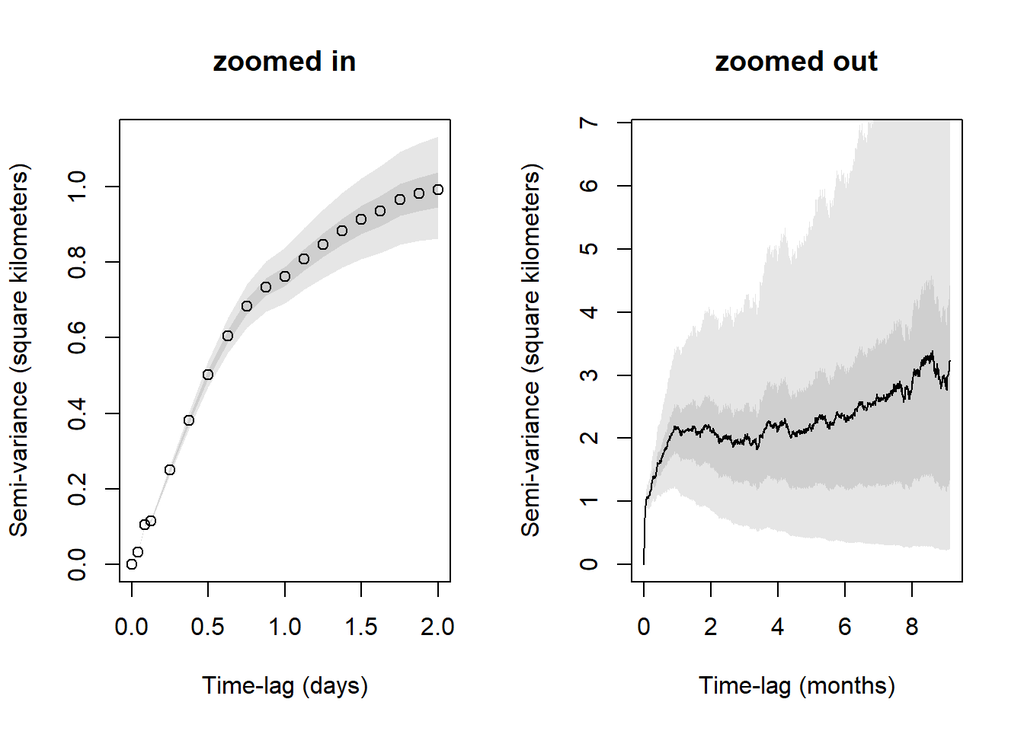

```r
# Investigate different time lags
par(mfrow=c(1,2))
plot(vg.karbolo, xlim=xlim, level=level)
title("zoomed in")

plot(vg.karbolo, fraction = 0.65, level=level)
title("zoomed out")
```

```r
# Variogram Model Selection, let the program take an initial guess based on the data
#GUESS <- ctmm.guess(wild[[An]], interactive=TRUE)
GUESS <- ctmm.guess(wild[[An]], interactive=FALSE)

# We can then use this GUESS to fit and evaluate a number of different movement models
FITS <- ctmm.select(wild[[An]], GUESS, verbose = TRUE, cores = 2) # Be patient, there's a lot happening in the background.

# Summarize the results in a human-readable format
summary(FITS) # OUF is the best model
```

```
##                        ΔAICc        ΔRMSPE (m) DOF[area]
## OUF anisotropic      0.00000          375.2450  235.0963
## OU anisotropic      92.77999          376.6726  204.6982
## OUF isotropic      140.61194          440.7835  224.0118
## OUf anisotropic   4893.43648            0.0000 1755.7493
```

```r
# Summarize the model of interest
# This is super cool, but ignore the initial area reported here - that's the Gaussian estimate.  We'll refine that below
summary(FITS[[1]])
```

```
## $name
## [1] "OUF anisotropic"
##
## $DOF
##     mean     area    speed
## 124.0196 235.0963 194.2582
##
## $CI
##                                low       est      high
## area (square kilometers) 36.839240 42.042051 47.583516
## t[position] (days)        1.429104  1.649122  1.903012
## t[velocity] (minutes)     8.291405  9.971642 11.992376
## speed (kilometers/day)   18.498554 19.897664 21.295466
```

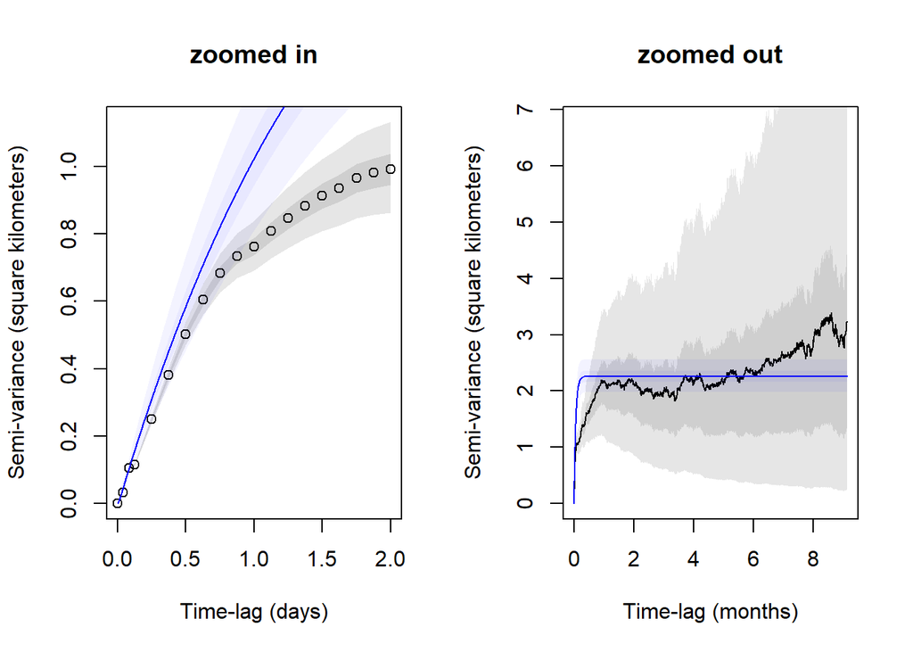

```r
# Outputs from the model are Tau - position, Tau - velocity, and Speed (Km/day)
# Tau position is the estimated home range crossing time
# Tau Velocity is the time over which the velocity (speed and direction) tends to remain the same.  You can think of it as the step time.

# Plot the variogram and the best fitting model
plot(vg.karbolo,FITS[[1]], xlim=xlim, level=level, col.CTMM = "blue")
title("zoomed in")

plot(vg.karbolo, FITS[[1]], fraction = 0.65, level=level, col.CTMM = "blue")
title("zoomed out")
```

```r
par(mfrow=c(1,1))
```

### Autocorrelated Kernel Density Estimation

Based on the best fit model, calculate the autocorrelated kernel density home range estimate. The function `akde` requires the 2D timeseries telemetry object and a CTMM movement model, which we created above called “FITS”.

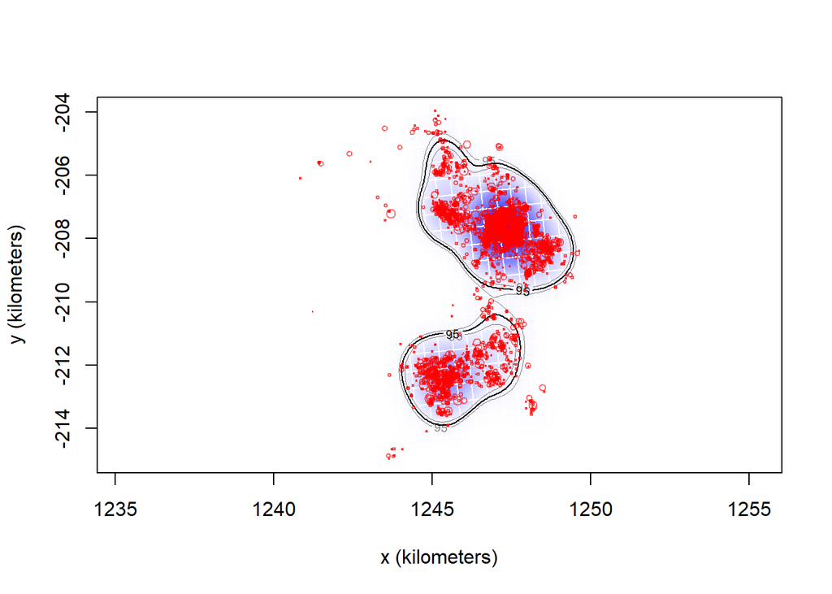

```r
# Calculate AKDE movement parameters and home range estimate
akde.est <- akde(data = wild[[An]], CTMM = FITS[[1]])
plot(wild[[An]], akde.est) # Plot the estimate
```

```r
# Summarize AKDE output, which includes a maximum likelihood estimate and confidence intervals..
summary(akde.est)
```

```
## $DOF
##      area bandwidth
##  235.0963  895.5318
##
## $CI
##                               low      est     high
## area (square kilometers) 21.00431 23.97076 27.13028
```

# Next Steps

- Calculate AKDE home ranges for multiple analysis (use `lapply` function over the list of animals)
- Compare similarities and differences between animals (use `meta’ function to incorporate variance in estimates)
- Correct for GPS telemetry error (Chris has paper in review)